# Project 1: Wrangling, Exploration, Visualization

Cade Talley (cct847)

November 1, 2021

## Data Wrangling, Exploration, Visualization

### Cade Talley (cct847)

#### Introduction

For this project, I used three datasets imported from “fivethirtyeight” originally called “bad_drivers”, “state.x77” and “state_info”. The bad_drivers variables that were utilized for my project contain percentages of automotive accidents occurring from different things such as alcohol consumption, speeding and total number of driver fatalities/billion miles based on individual states. The state.x77 dataset contains numeric indicators such as population (per 100,000 scale), average income, illiteracy rate, life expectancy, and area per square mile for each categorical state variable. The “state_info” dataset was added during the later part of this project after joining only the first two datasets initially, then realizing I needed additional categorical variables such as which region and division each state belongs to.

I found the combination of these datasets interesting because they allow us to see a larger picture of car crash indicators by key numeric indicators against categorical variables other than states. I also feel that this is such a prevalent issue in our country, specifically because we rely on personal means of transportation more heavily than other wealthy countries.

```r
# read your datasets in here, e.g., with read_csv()
library(tidyverse)
library(ggplot2)
library(fivethirtyeight)
library(knitr)
library(kableExtra)
library(gt)
data1 <- as.data.frame(bad_drivers)
data2 <- as.data.frame(state.x77)
data3 <- as.data.frame(state_info)
```

#### Tidying: Reshaping

The first line of code below adds the state’s names to the first column, as the imported dataset did not have the names defined as a variable within the column. I chose to wait until the wrangling sections to reshape one of my summary statistics table with pivot tidying methods as all of my datasets were tidy to begin with.

```r
# column 1 needs to have variable as 'state'
info <- tibble::rownames_to_column(data2, "state")
drive <- as.data.frame(bad_drivers)
```

#### Joining/Merging

```r
# your joining code
state_join <- left_join(info, drive, by = "state")
state_join <- left_join(state_join, data3, by = "state")
# Calculate total observations/rows in each dataset IDs the
# datasets have common
nrow(drive)
```

```
## [1] 51
```

```r
nrow(info)
```

```
## [1] 50
```

```r
nrow(data3)
```

```
## [1] 51
```

The state_join dataset joins all three of the original datasets (first: the info and drive datasets, then the first two joined with the third dataset). The first chunk of code counts the number of rows in the columns, showing “drive” containing 51 rows, “info” containing 50 rows, and “data3” containing 51 rows.

```r
# unique IDs in drive dataset
unique(drive$state)
```

```
##  [1] "Alabama"              "Alaska"               "Arizona"
##  [4] "Arkansas"             "California"           "Colorado"
##  [7] "Connecticut"          "Delaware"             "District of Columbia"
## [10] "Florida"              "Georgia"              "Hawaii"
## [13] "Idaho"                "Illinois"             "Indiana"
## [16] "Iowa"                 "Kansas"               "Kentucky"
## [19] "Louisiana"            "Maine"                "Maryland"
## [22] "Massachusetts"        "Michigan"             "Minnesota"
## [25] "Mississippi"          "Missouri"             "Montana"
## [28] "Nebraska"             "Nevada"               "New Hampshire"
## [31] "New Jersey"           "New Mexico"           "New York"
## [34] "North Carolina"       "North Dakota"         "Ohio"
## [37] "Oklahoma"             "Oregon"               "Pennsylvania"
## [40] "Rhode Island"         "South Carolina"       "South Dakota"
## [43] "Tennessee"            "Texas"                "Utah"
## [46] "Vermont"              "Virginia"             "Washington"
## [49] "West Virginia"        "Wisconsin"            "Wyoming"
```

```r
# unique IDs in info dataset
unique(info$state)
```

```
##  [1] "Alabama"        "Alaska"         "Arizona"        "Arkansas"
##  [5] "California"     "Colorado"       "Connecticut"    "Delaware"
##  [9] "Florida"        "Georgia"        "Hawaii"         "Idaho"
## [13] "Illinois"       "Indiana"        "Iowa"           "Kansas"
## [17] "Kentucky"       "Louisiana"      "Maine"          "Maryland"
## [21] "Massachusetts"  "Michigan"       "Minnesota"      "Mississippi"
## [25] "Missouri"       "Montana"        "Nebraska"       "Nevada"
## [29] "New Hampshire"  "New Jersey"     "New Mexico"     "New York"
## [33] "North Carolina" "North Dakota"   "Ohio"           "Oklahoma"
## [37] "Oregon"         "Pennsylvania"   "Rhode Island"   "South Carolina"
## [41] "South Dakota"   "Tennessee"      "Texas"          "Utah"
## [45] "Vermont"        "Virginia"       "Washington"     "West Virginia"
## [49] "Wisconsin"      "Wyoming"
```

```r
# unique IDs in data3 dataset
unique(data3$state)
```

```
##  [1] "Alabama"              "Alaska"               "Arizona"
##  [4] "Arkansas"             "California"           "Colorado"
##  [7] "Connecticut"          "Delaware"             "Florida"
## [10] "Georgia"              "Hawaii"               "Idaho"
## [13] "Illinois"             "Indiana"              "Iowa"
## [16] "Kansas"               "Kentucky"             "Louisiana"
## [19] "Maine"                "Maryland"             "Massachusetts"
## [22] "Michigan"             "Minnesota"            "Mississippi"
## [25] "Missouri"             "Montana"              "Nebraska"
## [28] "Nevada"               "New Hampshire"        "New Jersey"
## [31] "New Mexico"           "New York"             "North Carolina"
## [34] "North Dakota"         "Ohio"                 "Oklahoma"
## [37] "Oregon"               "Pennsylvania"         "Rhode Island"
## [40] "South Carolina"       "South Dakota"         "Tennessee"
## [43] "Texas"                "Utah"                 "Vermont"
## [46] "Virginia"             "Washington"           "West Virginia"
## [49] "Wisconsin"            "Wyoming"              "District of Columbia"
```

This chunk of code uses the unique function to identify each unique ID “state” present in all three of the datasets.

```r
# IDs that appear in drive but not info
anti_join(drive, info, by = "state")
```

```
##                  state num_drivers perc_speeding perc_alcohol
## 1 District of Columbia         5.9            34           27
##   perc_not_distracted perc_no_previous insurance_premiums losses
## 1                 100              100            1273.89 136.05
```

```r
# IDs that appear in drive but not data3
anti_join(drive, data3, by = "state")
```

```
## [1] state               num_drivers         perc_speeding
## [4] perc_alcohol        perc_not_distracted perc_no_previous
## [7] insurance_premiums  losses
## <0 rows> (or 0-length row.names)
```

```r
# IDs that appear in data3 but not info
anti_join(data3, info, by = "state")
```

```
##                  state state_abbrev       division region
## 1 District of Columbia           DC South Atlantic  South
```

To identify which IDs were present in some of the datasets but not the others, I used antijoin, showing that the datasets “drive” and “data3” both have the unique ID for Washington DC, while the dataset “info” does not include DC as an ID.

```r
# IDs drive and info have in common
inner_join(drive, info, by = "state")[, 1]
```

```
##  [1] "Alabama"        "Alaska"         "Arizona"        "Arkansas"
##  [5] "California"     "Colorado"       "Connecticut"    "Delaware"
##  [9] "Florida"        "Georgia"        "Hawaii"         "Idaho"
## [13] "Illinois"       "Indiana"        "Iowa"           "Kansas"
## [17] "Kentucky"       "Louisiana"      "Maine"          "Maryland"
## [21] "Massachusetts"  "Michigan"       "Minnesota"      "Mississippi"
## [25] "Missouri"       "Montana"        "Nebraska"       "Nevada"
## [29] "New Hampshire"  "New Jersey"     "New Mexico"     "New York"
## [33] "North Carolina" "North Dakota"   "Ohio"           "Oklahoma"
## [37] "Oregon"         "Pennsylvania"   "Rhode Island"   "South Carolina"
## [41] "South Dakota"   "Tennessee"      "Texas"          "Utah"
## [45] "Vermont"        "Virginia"       "Washington"     "West Virginia"
## [49] "Wisconsin"      "Wyoming"
```

```r
# IDs drive and data3 have in common
inner_join(drive, data3, by = "state")[, 1]
```

```
##  [1] "Alabama"              "Alaska"               "Arizona"
##  [4] "Arkansas"             "California"           "Colorado"
##  [7] "Connecticut"          "Delaware"             "District of Columbia"
## [10] "Florida"              "Georgia"              "Hawaii"
## [13] "Idaho"                "Illinois"             "Indiana"
## [16] "Iowa"                 "Kansas"               "Kentucky"
## [19] "Louisiana"            "Maine"                "Maryland"
## [22] "Massachusetts"        "Michigan"             "Minnesota"
## [25] "Mississippi"          "Missouri"             "Montana"
## [28] "Nebraska"             "Nevada"               "New Hampshire"
## [31] "New Jersey"           "New Mexico"           "New York"
## [34] "North Carolina"       "North Dakota"         "Ohio"
## [37] "Oklahoma"             "Oregon"               "Pennsylvania"
## [40] "Rhode Island"         "South Carolina"       "South Dakota"
## [43] "Tennessee"            "Texas"                "Utah"
## [46] "Vermont"              "Virginia"             "Washington"
## [49] "West Virginia"        "Wisconsin"            "Wyoming"
```

```r
# IDs data3 and info have in common
inner_join(data3, info, by = "state")[, 1]
```

```
##  [1] "Alabama"        "Alaska"         "Arizona"        "Arkansas"
##  [5] "California"     "Colorado"       "Connecticut"    "Delaware"
##  [9] "Florida"        "Georgia"        "Hawaii"         "Idaho"
## [13] "Illinois"       "Indiana"        "Iowa"           "Kansas"
## [17] "Kentucky"       "Louisiana"      "Maine"          "Maryland"
## [21] "Massachusetts"  "Michigan"       "Minnesota"      "Mississippi"
## [25] "Missouri"       "Montana"        "Nebraska"       "Nevada"
## [29] "New Hampshire"  "New Jersey"     "New Mexico"     "New York"
## [33] "North Carolina" "North Dakota"   "Ohio"           "Oklahoma"
## [37] "Oregon"         "Pennsylvania"   "Rhode Island"   "South Carolina"
## [41] "South Dakota"   "Tennessee"      "Texas"          "Utah"
## [45] "Vermont"        "Virginia"       "Washington"     "West Virginia"
## [49] "Wisconsin"      "Wyoming"
```

Finally, I used inner join in the final chunk of the Joining/Merging section to identify the state IDs the three datasets had in common, which included all of the states besides Washington DC for the “info” dataset.

#### Wrangling

```r
# new variable that is function of 2 variables
state_join <- state_join %>% mutate(death_land_ratio = ((num_drivers *
    1e+09)/(Area^2)))
state_join <- state_join %>% mutate(death_land_ratio = format(state_join$death_land_ratio,
    scientific = FALSE, digits = 3))
# replace ratio as numeric variable
state_join$death_land_ratio <- as.numeric(as.character(state_join$death_land_ratio))
ratio_table <- state_join %>% group_by(state) %>% summarize(death_land_ratio)
ratio_table %>% kable()
```

| state | death_land_ratio |
| --- | --- |
| Alabama | 7.3115 |
| Alaska | 0.0564 |
| Arizona | 1.4460 |
| Arkansas | 8.3016 |
| California | 0.4908 |
| Colorado | 1.2631 |
| Connecticut | 456.8713 |
| Delaware | 4123.8961 |
| Florida | 6.1181 |
| Georgia | 4.6257 |
| Hawaii | 423.9277 |
| Idaho | 2.2383 |
| Illinois | 4.1186 |
| Indiana | 11.1282 |
| Iowa | 5.0169 |
| Kansas | 2.6610 |
| Kentucky | 13.6122 |
| Louisiana | 10.1550 |
| Maine | 15.7942 |
| Maryland | 127.7702 |
| Massachusetts | 133.8857 |
| Michigan | 4.3678 |
| Minnesota | 1.5270 |
| Mississippi | 7.8680 |
| Missouri | 3.3821 |
| Montana | 1.0096 |
| Nebraska | 2.5472 |
| Nevada | 1.2173 |
| New Hampshire | 142.3545 |
| New Jersey | 198.0008 |
| New Mexico | 1.2482 |
| New York | 5.3763 |
| North Carolina | 7.0551 |
| North Dakota | 4.9805 |
| Ohio | 8.3981 |
| Oklahoma | 4.2063 |
| Oregon | 1.3836 |
| Pennsylvania | 9.0013 |
| Rhode Island | 10087.2318 |
| South Carolina | 26.1617 |
| South Dakota | 3.3627 |
| Tennessee | 11.4168 |
| Texas | 0.2823 |
| Utah | 1.6766 |
| Vermont | 158.3655 |
| Virginia | 8.0255 |
| Washington | 2.3919 |
| West Virginia | 41.0795 |
| Wisconsin | 4.6522 |
| Wyoming | 1.8416 |

In the first chunk of the wrangling section, I decided to create a variable that calculated the ratio of driver fatalities to state land area. Since the “num_drivers” variable was fatalities per billion miles and state area was given in square miles, I decided to include a conversion seen in the equation above to simplify the units. Additionally, I ran into some issues with the output variable class, so I converted the resulting “death_land_ratio” variable to a numeric one and removed the scientific notation for aesthetic purposes.

```r
# use mutate, filter, select, arrange, group_by, summarize
state_join <- state_join %>% select(-Frost, -losses, -insurance_premiums,
    -state_abbrev, -Murder, -perc_no_previous, -Income, -perc_not_distracted,
    -"HS Grad")

# use stringr (str_detect or str_replace, str_view)

state_join <- state_join %>% mutate(division = str_replace_all(division,
    "-", " "))
unique(state_join$division)
```

```
## [1] "East South Central" "Pacific"            "Mountain"
## [4] "West South Central" "New England"        "South Atlantic"
## [7] "East North Central" "West North Central" "Mid Atlantic"
```

In this chunk of code, I removed some of the variables that I found useless and redundant for the purposes of this project. To demonstrate the use of “stringr” function, I removed a hyphen from the “Mid-Atlantic” division ID.

```r
# summary stats: mean, sd, var, n, quantile, min, max,
# n_distinct, cor


# sum stat table of mean and median grouped by region for
# each numeric variable
table1 <- state_join %>% group_by(region) %>% summarize_if(is.numeric,
    list(`_mean` = mean, `_median` = median)) %>% pivot_longer(contains("_")) %>%
    separate(name, into = c("Region", "Stat"), sep = "__") %>%
    mutate_if(is.numeric, round, 3)

table1 %>% kable()
```

| region | Region | Stat | value |
| --- | --- | --- | --- |
| Midwest | Population | mean | 4803.000 |
| Midwest | Illiteracy | mean | 0.700 |
| Midwest | Life Exp | mean | 71.767 |
| Midwest | Area | mean | 62652.000 |
| Midwest | num_drivers | mean | 15.558 |
| Midwest | perc_speeding | mean | 27.167 |
| Midwest | perc_alcohol | mean | 31.667 |
| Midwest | death_land_ratio | mean | 4.679 |
| Midwest | Population | median | 4255.000 |
| Midwest | Illiteracy | median | 0.700 |
| Midwest | Life Exp | median | 72.280 |
| Midwest | Area | median | 62906.000 |
| Midwest | num_drivers | median | 14.700 |
| Midwest | perc_speeding | median | 26.000 |
| Midwest | perc_alcohol | median | 33.000 |
| Midwest | death_land_ratio | median | 4.243 |
| Northeast | Population | mean | 5495.111 |
| Northeast | Illiteracy | mean | 1.000 |
| Northeast | Life Exp | mean | 71.264 |
| Northeast | Area | mean | 18141.000 |
| Northeast | num_drivers | mean | 12.456 |
| Northeast | perc_speeding | mean | 33.778 |
| Northeast | perc_alcohol | mean | 31.889 |
| Northeast | death_land_ratio | mean | 1245.209 |
| Northeast | Population | median | 3100.000 |
| Northeast | Illiteracy | median | 1.100 |
| Northeast | Life Exp | median | 71.230 |
| Northeast | Area | median | 9027.000 |
| Northeast | num_drivers | median | 11.600 |
| Northeast | perc_speeding | median | 34.000 |
| Northeast | perc_alcohol | median | 30.000 |
| Northeast | death_land_ratio | median | 142.355 |
| South | Population | mean | 4208.125 |
| South | Illiteracy | mean | 1.738 |
| South | Life Exp | mean | 69.706 |
| South | Area | mean | 54605.125 |
| South | num_drivers | mean | 18.681 |
| South | perc_speeding | mean | 28.812 |
| South | perc_alcohol | mean | 30.125 |
| South | death_land_ratio | mean | 275.493 |
| South | Population | median | 3710.500 |
| South | Illiteracy | median | 1.750 |
| South | Life Exp | median | 70.070 |
| South | Area | median | 46113.000 |
| South | num_drivers | median | 19.100 |
| South | perc_speeding | median | 33.000 |
| South | perc_alcohol | median | 29.500 |
| South | death_land_ratio | median | 8.164 |
| West | Population | mean | 2915.308 |
| West | Illiteracy | mean | 1.023 |
| West | Life Exp | mean | 71.235 |
| West | Area | mean | 134463.000 |
| West | num_drivers | mean | 15.515 |
| West | perc_speeding | mean | 37.923 |
| West | perc_alcohol | mean | 29.923 |
| West | death_land_ratio | mean | 33.861 |
| West | Population | median | 1144.000 |
| West | Illiteracy | median | 0.600 |
| West | Life Exp | median | 71.710 |
| West | Area | median | 103766.000 |
| West | num_drivers | median | 15.300 |
| West | perc_speeding | median | 37.000 |
| West | perc_alcohol | median | 28.000 |
| West | death_land_ratio | median | 1.384 |

This table was created to display the mean and median of each numeric variable in the joined dataset.For simplicity and aesthetic purposes, I grouped these summary statistics by region and pivoted the statistic values into a column. This grouping allows us to see the spread of each mean/median numeric variable over the regions, and it was piped into the kable package to improve it’s look.

```r
# other sum stat tables (min, max, sd) all grouped by region
# because individual states would not return summary values
table_min <- state_join %>% group_by(region) %>% summarize_if(is.numeric,
    min)
table_min %>% kable()
```

| region | Population | Illiteracy | Life Exp | Area | num_drivers | perc_speeding | perc_alcohol | death_land_ratio |
| --- | --- | --- | --- | --- | --- | --- | --- | --- |
| Midwest | 637 | 0.5 | 70.14 | 36097 | 9.6 | 13 | 24 | 1.5270 |
| Northeast | 472 | 0.6 | 70.39 | 1049 | 8.2 | 16 | 28 | 5.3763 |
| South | 579 | 0.9 | 67.96 | 1982 | 12.5 | 15 | 23 | 0.2823 |
| West | 365 | 0.5 | 69.03 | 6425 | 10.6 | 19 | 16 | 0.0564 |

```r
table_max <- state_join %>% group_by(region) %>% summarize_if(is.numeric,
    max)
table_max %>% kable()
```

| region | Population | Illiteracy | Life Exp | Area | num_drivers | perc_speeding | perc_alcohol | death_land_ratio |
| --- | --- | --- | --- | --- | --- | --- | --- | --- |
| Midwest | 11197 | 0.9 | 72.96 | 81787 | 23.9 | 43 | 42 | 11.1282 |
| Northeast | 18076 | 1.4 | 72.48 | 47831 | 18.2 | 50 | 38 | 10087.2318 |
| South | 12237 | 2.8 | 71.42 | 262134 | 23.9 | 40 | 41 | 4123.8961 |
| West | 21198 | 2.2 | 73.60 | 566432 | 21.4 | 54 | 44 | 423.9277 |

```r
table_sd <- state_join %>% group_by(region) %>% summarize_if(is.numeric,
    sd)
table_sd %>% kable()
```

| region | Population | Illiteracy | Life Exp | Area | num_drivers | perc_speeding | perc_alcohol | death_land_ratio |
| --- | --- | --- | --- | --- | --- | --- | --- | --- |
| Midwest | 3702.828 | 0.1414214 | 1.0367285 | 14967.02 | 3.588988 | 8.397330 | 4.942089 | 2.662998 |
| Northeast | 6079.565 | 0.2783882 | 0.7438769 | 18075.69 | 2.879284 | 10.497354 | 3.515837 | 3318.676321 |
| South | 2779.508 | 0.5524189 | 1.0221994 | 57965.27 | 3.421543 | 9.389489 | 4.514791 | 1026.699212 |
| West | 5578.607 | 0.6084870 | 1.3519715 | 134981.73 | 3.325118 | 7.815173 | 7.029243 | 117.202206 |

```r
# Comparing the numeric statistics of southern region (not
# including TX) with those of Texas
south_region_table <- state_join %>% filter(region == "South",
    state != "Texas") %>% summarize_if(is.numeric, mean)


texas_table <- state_join %>% filter(state == "Texas") %>% summarize_if(is.numeric,
    mean)

two_regions = rbind(south_region_table, texas_table)
rownames(two_regions) = c("south", "texas")
two_regions %>% kable()
```

|  | Population | Illiteracy | Life Exp | Area | num_drivers | perc_speeding | perc_alcohol | death_land_ratio |
| --- | --- | --- | --- | --- | --- | --- | --- | --- |
| south | 3672.867 | 1.706667 | 69.62667 | 40769.87 | 18.63333 | 28.06667 | 29.6 | 293.8402 |
| texas | 12237.000 | 2.200000 | 70.90000 | 262134.00 | 19.40000 | 40.00000 | 38.0 | 0.2823 |

I thought it would be interesting to compare the numeric variable statistics of all states in the southern region, excluding Texas, with those of Texas. This table is the result, which shows significant differences in the population, accident fatalities involved with alcohol and death-to-land ratio.

```r
# categorical variable count by region: number of states in
# each region and division
region_table <- state_join %>% group_by(region) %>% select(state) %>%
    summarize(count = n()) %>% arrange(desc(count))
region_table %>% kable()
```

| region | count |
| --- | --- |
| South | 16 |
| West | 13 |
| Midwest | 12 |
| Northeast | 9 |

```r
division_table <- state_join %>% group_by(division) %>% select(state) %>%
    summarize(count = n()) %>% arrange(desc(count))
division_table %>% kable()
```

| division | count |
| --- | --- |
| Mountain | 8 |
| South Atlantic | 8 |
| West North Central | 7 |
| New England | 6 |
| East North Central | 5 |
| Pacific | 5 |
| East South Central | 4 |
| West South Central | 4 |
| Mid Atlantic | 3 |

These two tables show the total number of states in each categorical variable. The first table shows the number of states in each US region, while the second table shows the number of states in each US division.

```r
# Defined function of percent of people speeding involved in
# accidents by the total population of that state to find
# number of people in population in accidents that were
# speeding

num_speed <- function(x) {
    x$perc_speeding * (x$Population)
}
a = state_join %>% summarize(Num_Speed = num_speed(.))
a = cbind(state = state_join$state, a)
knitr::kable(a)
```

| state | Num_Speed |
| --- | --- |
| Alabama | 140985 |
| Alaska | 14965 |
| Arizona | 77420 |
| Arkansas | 37980 |
| California | 741930 |
| Colorado | 94017 |
| Connecticut | 142600 |
| Delaware | 22002 |
| Florida | 173817 |
| Georgia | 93689 |
| Hawaii | 46872 |
| Idaho | 29268 |
| Illinois | 403092 |
| Indiana | 132825 |
| Iowa | 48637 |
| Kansas | 61560 |
| Kentucky | 64353 |
| Louisiana | 133210 |
| Maine | 40204 |
| Maryland | 140148 |
| Massachusetts | 133722 |
| Michigan | 218664 |
| Minnesota | 90183 |
| Mississippi | 35115 |
| Missouri | 204981 |
| Montana | 29094 |
| Nebraska | 20072 |
| Nevada | 21830 |
| New Hampshire | 28420 |
| New Jersey | 117328 |
| New Mexico | 21736 |
| New York | 578432 |
| North Carolina | 212199 |
| North Dakota | 14651 |
| Ohio | 300580 |
| Oklahoma | 86880 |
| Oregon | 75372 |
| Pennsylvania | 593000 |
| Rhode Island | 31654 |
| South Carolina | 107008 |
| South Dakota | 21111 |
| Tennessee | 87633 |
| Texas | 489480 |
| Utah | 51729 |
| Vermont | 14160 |
| Virginia | 94639 |
| Washington | 149478 |
| West Virginia | 61166 |
| Wisconsin | 165204 |
| Wyoming | 15792 |

#### Visualizing

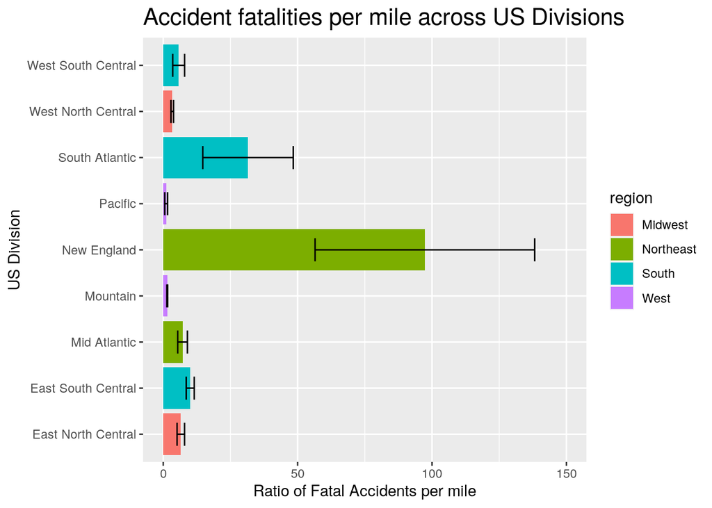

```r
ggplot(state_join, aes(x = death_land_ratio, y = division, fill = region)) +
    geom_bar(stat = "summary", fun = mean) + geom_errorbar(stat = "summary",
    fun.data = mean_se, width = 0.5) + xlim(0, 150) + xlab("Ratio of Fatal Accidents per mile") +
    ylab("US Division") + ggtitle("Accident fatalities per mile across US Divisions") +
    theme(plot.title = element_text(size = rel(1.5)))
```

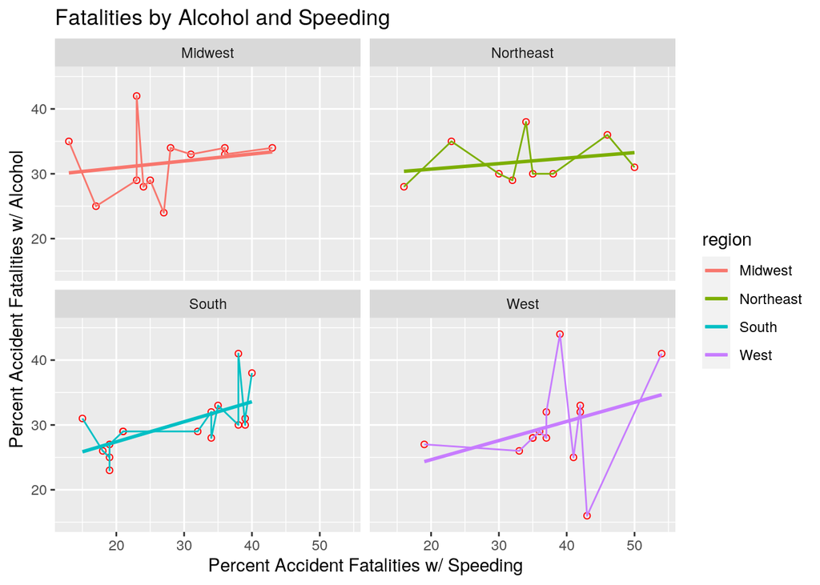

```r
ggplot(state_join, aes(x = perc_speeding, y = perc_alcohol, color = region)) +
    geom_point(shape = 1, color = "red") + geom_line(method = "lm",
    se = F) + scale_y_continuous(limits = c(15, 45)) + ylab("Percent Accident Fatalities w/ Alcohol") +
    xlab("Percent Accident Fatalities w/ Speeding") + ggtitle("Fatalities by Alcohol and Speeding") +
    facet_wrap(~region) + geom_smooth(method = lm, se = FALSE)
```

This facet wrapped line plot shows the percent of drivers involved in fatal automotive accidents who were speeding against those who were alcohol-impaired. To make this distribution more aesthetic, I facet wrapped by region and included a regression to look for correlation between driver fatalities. There appears to be a slightly positive correlation between the two variables for all four US regions, and the most positive correlation appears to be in the southern region.

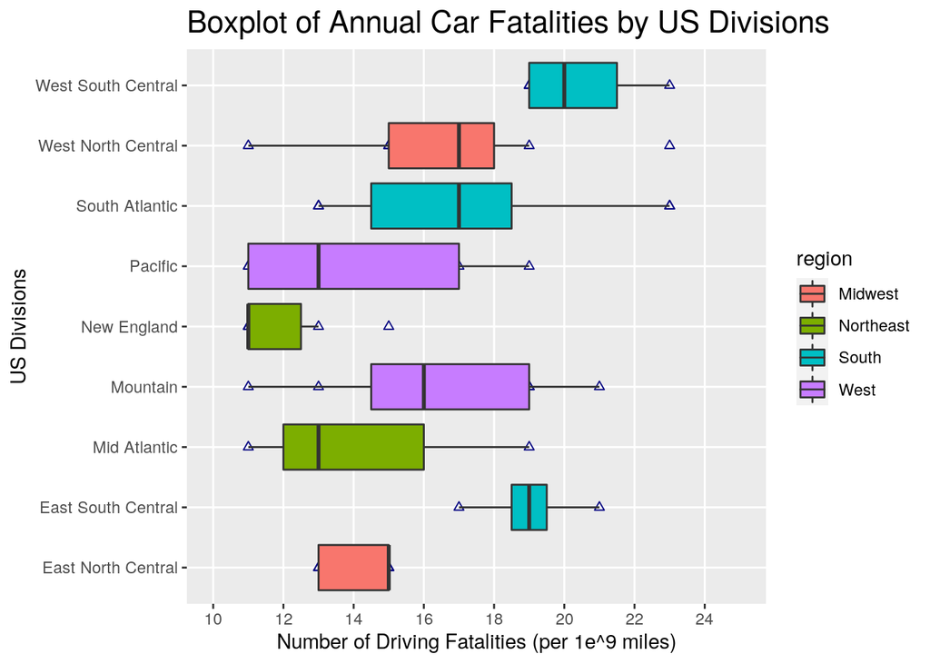

```r
ggplot(state_join, aes(x = num_drivers, y = division, fill = region)) +
    geom_point(shape = 2, color = "navy") + geom_boxplot() +
    scale_x_binned(limit = c(10, 25)) + ylab("US Divisions") +
    xlab("Number of Driving Fatalities (per 1e^9 miles)") + ggtitle("Boxplot of Annual Car Fatalities by US Divisions") +
    theme(plot.title = element_text(size = rel(1.5)))
```